In this exercise, we will predict the number of applications received using the other variables in the `College` data set.

1. Split the data set into a training set and a test set.

```r
set.seed(1)
model_results<-data.frame()
names(College)
```

```
##  [1] "Private"     "Apps"        "Accept"      "Enroll"      "Top10perc"
##  [6] "Top25perc"   "F.Undergrad" "P.Undergrad" "Outstate"    "Room.Board"
## [11] "Books"       "Personal"    "PhD"         "Terminal"    "S.F.Ratio"
## [16] "perc.alumni" "Expend"      "Grad.Rate"
```

```r
rp <- modelr::resample_partition(College, c(train = 0.7, test = 0.3))
training_set <- as_tibble(rp$train)
testing_set <- as_tibble(rp$test)

#train x and y
x_train <- model.matrix(Apps ~ ., training_set)
y_train <- training_set$Apps
# test x and y
x_test <- model.matrix(Apps ~ ., testing_set)
y_test <- testing_set$Apps
```

2. Fit a linear model using least squares on the training set, and report the test error obtained.

```r
# linear regression with normal error/residuals = gaussian
# default method for fit are literatively reweighted least squares (IWLS)
#glm_fit <- glm(Apps ~ ., training_set, family = "gaussian")

lm_fit<-lm(Apps ~ ., training_set)
summary(lm_fit)
```

```
##
## Call:
## lm(formula = Apps ~ ., data = training_set)
##
## Residuals:
##     Min      1Q  Median      3Q     Max
## -3375.5  -425.4   -31.3   308.0  6596.5
##
## Coefficients:
##               Estimate Std. Error t value Pr(>|t|)
## (Intercept) -972.27847  469.33960  -2.072 0.038792 *
## PrivateYes  -487.12099  162.38111  -3.000 0.002829 **
## Accept         1.25833    0.06001  20.969  < 2e-16 ***
## Enroll        -0.25520    0.23814  -1.072 0.284376
## Top10perc     51.90573    6.27747   8.269 1.12e-15 ***
## Top25perc    -18.28974    5.18388  -3.528 0.000455 ***
## F.Undergrad    0.06659    0.04109   1.621 0.105724
## P.Undergrad    0.02834    0.03520   0.805 0.421021
## Outstate      -0.07028    0.02185  -3.217 0.001378 **
## Room.Board     0.20726    0.05701   3.636 0.000304 ***
## Books          0.02845    0.29346   0.097 0.922810
## Personal       0.05835    0.07596   0.768 0.442715
## PhD           -6.62206    5.20917  -1.271 0.204209
## Terminal      -1.12602    5.65462  -0.199 0.842236
## S.F.Ratio     14.50414   14.52727   0.998 0.318542
## perc.alumni   -5.94940    4.75216  -1.252 0.211151
## Expend         0.09373    0.01382   6.784 3.16e-11 ***
## Grad.Rate      9.47815    3.49431   2.712 0.006898 **
## ---
## Signif. codes:  0 '***' 0.001 '**' 0.01 '*' 0.05 '.' 0.1 ' ' 1
##
## Residual standard error: 992.6 on 525 degrees of freedom
## Multiple R-squared:  0.9264, Adjusted R-squared:  0.924
## F-statistic: 388.8 on 17 and 525 DF,  p-value: < 2.2e-16
```

```r
#test error - the average error that results from using a statistical learning method to predict
# the response on a new observation.
# linear regression with normal error/residuals = gaussian
lm_test_error<-modelr::mse(lm_fit, testing_set)
lm_test_error # 1694261
```

```
## [1] 1694261
```

```r
lm_train_error<-modelr::mse(lm_fit, training_set)
lm_train_error # 952570.4
```

```
## [1] 952570.4
```

```r
TestError<-lm_test_error
TrainError<-lm_train_error
TheModel<-"LM"
NewRow<-data.frame(TheModel,TestError,TrainError)
model_results<-rbind(model_results,NewRow)
```

3. Fit a ridge regression model on the training set, with $\lambda$ chosen by cross-validation. Report the test error obtained.

```r
# Fit a ridge regression model on the training set, with $\lambda$ chosen by cross-validation.
bestlam <- cv.glmnet(x_train, y_train, alpha = 0, nfolds = 10)$lambda.min
ridge_fit0 <- glmnet(x_train, y_train, alpha = 0, lambda = bestlam)
ridge_fit0$beta %>% as.matrix() %>% as_tibble(rownames = "variable")
```

```
## # A tibble: 18 x 2
##    variable            s0
##    <chr>            <dbl>
##  1 (Intercept)    0
##  2 PrivateYes  -500.
##  3 Accept         0.728
##  4 Enroll         0.756
##  5 Top10perc     28.3
##  6 Top25perc     -1.29
##  7 F.Undergrad    0.112
##  8 P.Undergrad    0.0125
##  9 Outstate      -0.0157
## 10 Room.Board     0.239
## 11 Books          0.286
## 12 Personal      -0.00304
## 13 PhD           -0.896
## 14 Terminal      -2.85
## 15 S.F.Ratio      9.93
## 16 perc.alumni  -11.2
## 17 Expend         0.0873
## 18 Grad.Rate      9.33
```

```r
# Report the test error obtained.
ridge_fit<-glmnet(x_train, y_train, alpha = 0)
ridge_pred = predict(ridge_fit, s = bestlam, newx = x_test) # predict test data
ridge_test_error<-mean((ridge_pred - y_test)^2)
ridge_test_error # 3139492
```

```
## [1] 3139492
```

```r
ridge_pred = predict(ridge_fit, s = bestlam, newx = x_train) # predict train data
ridge_train_error<-mean((ridge_pred - y_train)^2)
ridge_train_error # 1119240
```

```
## [1] 1119240
```

```r
TestError<-ridge_test_error
TrainError<-ridge_train_error
TheModel<-"Ridge"
NewRow<-data.frame(TheModel,TestError,TrainError)
model_results<-rbind(model_results,NewRow)
```

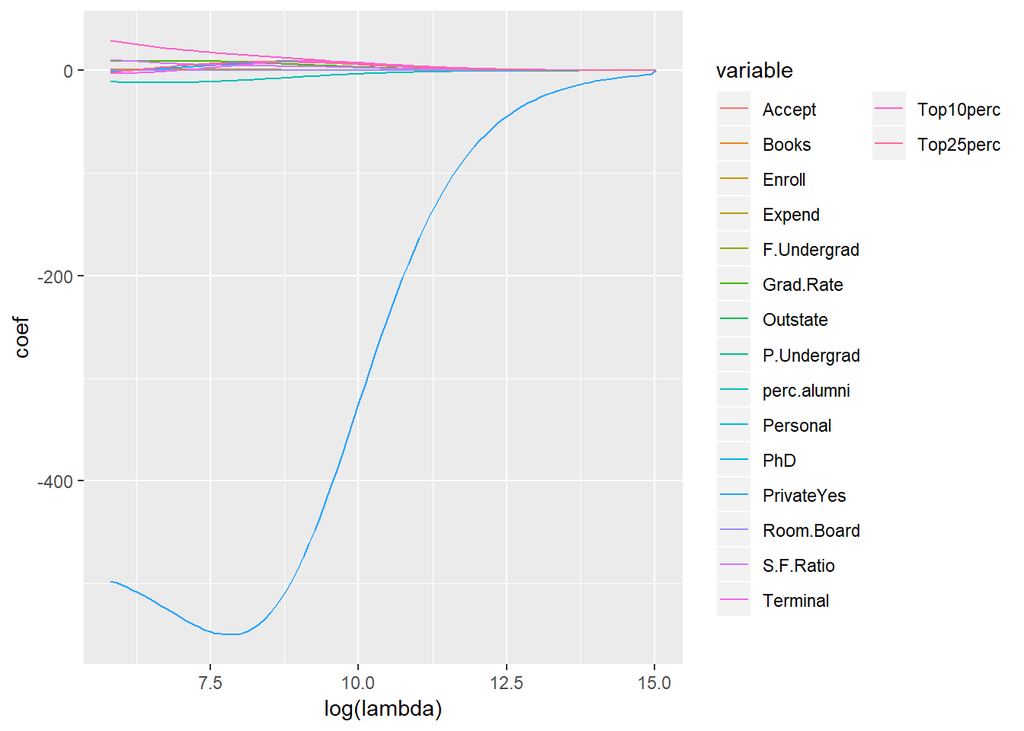

```r
# ridge regression - does better when most variables are useful. Coefficients only approach zero with lambda * penalty (coefficient^2). The minimum lambda is the
# model that is less biased to training data, which results in lower variance in testing data. A lambda of zero is the same as a least squares regression.
solution <- ridge_fit$beta %>%
    as.matrix() %>% as.data.frame() %>%
    set_names(ridge_fit$lambda) %>%
    rownames_to_column("variable") %>%
    filter(variable != "(Intercept)") %>%
    gather(-variable, key = "lambda", value = "coef", convert = TRUE)
ggplot(solution) + geom_line(aes(x = log(lambda), y = coef, color = variable)) +
    guides(col = guide_legend(nrow = 15))
```

4. Fit a lasso model on the training set, with $\lambda$ chosen by cross-validation. Report the test error obtained, along with the number of non-zero coefficient estimates.

```r
# Fit a lasso model on the training set, with $\lambda$ chosen by cross-validation.
# lasso does better when dropping variables because lasso converts variable coefficients that have the
# lowest amount of impact on the response to zero because it takes the coefficient absolute value*lambda.
# A lambda of zero is the same as a least squares regression. Increasing lambda decreases coefficients
# until they are zero. If a coefficient is high, i.e., steep positive slope, then a small increase in the
# variable leads to a greater increase in the response. Therefore, variables that already have a small
# impact in the response variable will reach zero coefficient faster than those that have a greater impact
# on the response, eliminating pointless variables.
bestlam <- cv.glmnet(x_train, y_train, alpha = 1, nfolds = 10)$lambda.min
lasso_fit0 <- glmnet(x_train, y_train, alpha = 1, lambda = bestlam)
lasso_fit0$beta %>% as.matrix() %>% as_tibble(rownames = "variable")
```

```
## # A tibble: 18 x 2
##    variable           s0
##    <chr>           <dbl>
##  1 (Intercept)    0
##  2 PrivateYes  -475.
##  3 Accept         1.21
##  4 Enroll         0
##  5 Top10perc     45.7
##  6 Top25perc    -13.2
##  7 F.Undergrad    0.0398
##  8 P.Undergrad    0.0242
##  9 Outstate      -0.0603
## 10 Room.Board     0.196
## 11 Books          0.0189
## 12 Personal       0.0476
## 13 PhD           -5.11
## 14 Terminal      -1.43
## 15 S.F.Ratio     10.4
## 16 perc.alumni   -6.22
## 17 Expend         0.0908
## 18 Grad.Rate      7.83
```

```r
# Report the test error obtained.
lasso_fit<-glmnet(x_train, y_train, alpha = 1)
lasso_pred = predict(lasso_fit, s = bestlam, newx = x_test) # predict test data
lasso_test_error<-mean((lasso_pred - y_test)^2)
lasso_test_error # 1768337
```

```
## [1] 1768337
```

```r
lasso_pred = predict(lasso_fit, s = bestlam, newx = x_train) # predict test data
lasso_train_error<-mean((lasso_pred - y_train)^2) # 957564.8
lasso_train_error # 957564.8
```

```
## [1] 957564.8
```

```r
TestError<-lasso_test_error
TrainError<-lasso_train_error
TheModel<-"Lasso"
NewRow<-data.frame(TheModel,TestError,TrainError)
model_results<-rbind(model_results,NewRow)

ncol(training_set) # 18
```

```
## [1] 18
```

```r
# the number of non-zero coefficient estimates - in the min lasso_fit0, 16 of 17 (1 response) variables are kept as explanatory -
# only 1 variable is reducted to 0.
nonZeroEst<-length(lasso_fit0$beta@x) # 16
nonZeroEst
```

```
## [1] 16
```

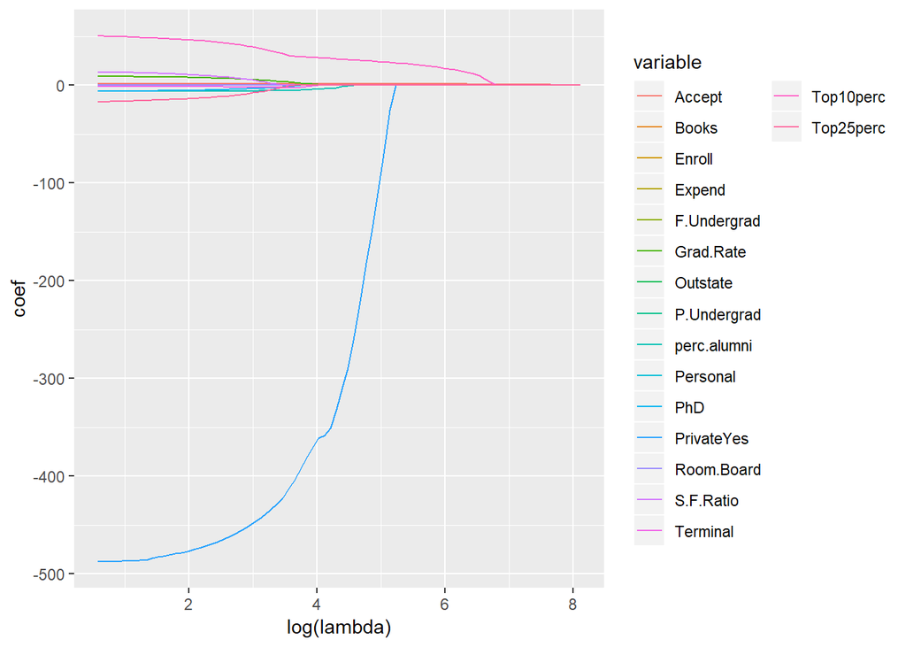

```r
solution <- lasso_fit$beta %>%
    as.matrix() %>% as.data.frame() %>%
    set_names(lasso_fit$lambda) %>%
    rownames_to_column("variable") %>%
    filter(variable != "(Intercept)") %>%
    gather(-variable, key = "lambda", value = "coef", convert = TRUE)
ggplot(solution) + geom_line(aes(x = log(lambda), y = coef, color = variable)) +
    guides(col = guide_legend(nrow = 15))
```

5. Fit a PCR model on the training set, with $M$ chosen by cross-validation. Report the test error obtained, along with the value of $M$ selected by cross-validation.

```r
# Fit a PCR model on the training set, with $M$ chosen by cross-validation.
# https://www.youtube.com/watch?v=-5nnciZ9hgc
# principal component regression
# solves issues about:
# dimensionality of the dataset - the number of samples is not necessarily > the
# number of variables
# colinearity between the x-variables

#pc <- princomp(x_train)
#pc$scores[, 1:5]  # show first 5 scores

pcr_fit <- pcr(Apps ~ ., data = training_set, scale = TRUE, validation = "CV")
MSEP(pcr_fit, estimate = "CV")
```

```
## (Intercept)      1 comps      2 comps      3 comps      4 comps
##    12992899     12232208      2762258      2749193      2400646
##     5 comps      6 comps      7 comps      8 comps      9 comps
##     2083193      1655700      1522366      1530216      1452293
##    10 comps     11 comps     12 comps     13 comps     14 comps
##     1387446      1395894      1405190      1393906      1399411
##    15 comps     16 comps     17 comps
##     1422209      1111380      1101788
```

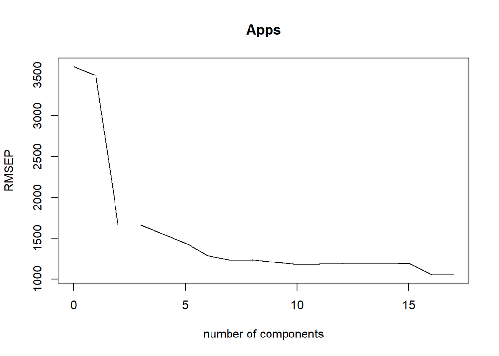

```r
# https://www.vub.ac.be/fabi/multi/pcr/chaps/chap13.html
# RMSEP is the root mean square error of prediction
# PARSIMONY - it has been proposed to use the first local minimum or a deflection point is used instead of the global minimum (which is too complex &
# does not generalize well to test data). If there is only a small difference between the RMSEP of the minimum and a model with less complexity,
# the latter is often chosen.
# for this model the first local minimum/deflection point is at approximately 5 principal components
plot(pcr_fit, "validation", estimate = "CV")
```

```r
#validationplot(pcr_fit, val.type="MSEP")

# with 5 pcs, 75% of the variation is explained in the x variables and 85% of the variation is explained in Apps
summary(pcr_fit)
```

```
## Data:    X dimension: 543 17
##  Y dimension: 543 1
## Fit method: svdpc
## Number of components considered: 17
##
## VALIDATION: RMSEP
## Cross-validated using 10 random segments.
##        (Intercept)  1 comps  2 comps  3 comps  4 comps  5 comps  6 comps
## CV            3605     3497     1662     1658     1549     1443     1287
## adjCV         3605     3498     1660     1657     1547     1424     1284
##        7 comps  8 comps  9 comps  10 comps  11 comps  12 comps  13 comps
## CV        1234     1237     1205      1178      1181      1185      1181
## adjCV     1230     1235     1204      1176      1180      1183      1178
##        14 comps  15 comps  16 comps  17 comps
## CV         1183      1193      1054      1050
## adjCV      1181      1190      1051      1046
##
## TRAINING: % variance explained
##       1 comps  2 comps  3 comps  4 comps  5 comps  6 comps  7 comps
## X      31.714    57.57    64.51    70.23    75.49    80.43    84.17
## Apps    6.162    79.25    79.54    82.78    85.64    87.73    88.67
##       8 comps  9 comps  10 comps  11 comps  12 comps  13 comps  14 comps
## X       87.69    90.75     93.15     95.27      97.0     98.07     98.95
## Apps    88.73    89.29     89.75     89.79      89.8     89.94     89.95
##       15 comps  16 comps  17 comps
## X        99.48     99.86    100.00
## Apps     89.95     92.39     92.64
```

```r
# Report the test error obtained, along with the value of $M$ chosen by cross-validation.
pcr_pred<-predict (pcr_fit, testing_set, ncomp=5)
pcr_test_error<-mean((pcr_pred-testing_set$Apps)^2)
pcr_test_error # 4933134
```

```
## [1] 4933134
```

```r
pcr_pred<-predict (pcr_fit, training_set, ncomp=5)
pcr_train_error<-mean((pcr_pred-training_set$Apps)^2)
pcr_train_error # 1858407
```

```
## [1] 1858407
```